# 01_EDA

### **Normalización del dataset**

Manipulamos los datos para conseguir un DataFrame donde cada fila represente nuestra unidad de estudio. En este caso, la unidad de estudio que vamos a seleccionar son los automóviles con conductor. Es decir, omitiremos personas que iban en bicicleta o peatones.

1. Buscamos las columnas que identifiquen únicamente cada accidente.

```python
col_idf = df.columns[:15]
```

```python
col_idf.values
```

```
array(['C_YEAR', 'C_MNTH', 'C_WDAY', 'C_HOUR', 'C_SEV', 'C_VEHS',
       'C_CONF', 'C_RCFG', 'C_WTHR', 'C_RSUR', 'C_RALN', 'C_TRAF', 'V_ID',
       'V_TYPE', 'V_YEAR'], dtype=object)
```

```python
df.sort_values(by=['C_YEAR', 'C_MNTH', 'C_WDAY', 'C_HOUR', 'C_SEV', 'C_VEHS',
       'C_CONF', 'C_RCFG', 'C_WTHR', 'C_RSUR', 'C_RALN', 'C_TRAF', 'V_ID',
       'V_TYPE', 'V_YEAR'], inplace=True)
```

1. Ahora hacemos una agrupación y comprobamos cuántos coches hay en cada accidente.

```python
df.groupby(by=['C_YEAR', 'C_MNTH', 'C_WDAY', 'C_HOUR', 'C_SEV', 'C_VEHS',
       'C_CONF', 'C_RCFG', 'C_WTHR', 'C_RSUR', 'C_RALN', 'C_TRAF', 'V_ID',
       'V_TYPE', 'V_YEAR']).size().reset_index().sample(15)
```

|  | C_YEAR | C_MNTH | C_WDAY | C_HOUR | C_SEV | C_VEHS | C_CONF | C_RCFG | C_WTHR | C_RSUR | C_RALN | C_TRAF | V_ID | V_TYPE | V_YEAR | 0 |
| --- | --- | --- | --- | --- | --- | --- | --- | --- | --- | --- | --- | --- | --- | --- | --- | --- |
| 2779525 | 2009 | 02 | 7 | 21 | 2 | 02 | 32 | 01 | 1 | 1 | 1 | 18 | 01 | 07 | 1994 | 1 |
| 1443569 | 2004 | 01 | 4 | 09 | 2 | 02 | 24 | 01 | 1 | 5 | 1 | 03 | 02 | 01 | 2003 | 1 |
| 2801562 | 2009 | 04 | 3 | 15 | 2 | 05 | 31 | 02 | 3 | 2 | 1 | 02 | 01 | 01 | 1999 | 1 |
| 3486004 | 2012 | 03 | 6 | 09 | 2 | 02 | 33 | 02 | 1 | 1 | 1 | 03 | 02 | 17 | NNNN | 1 |
| 3865012 | 2013 | 11 | 5 | 07 | 2 | 04 | 21 | 01 | 1 | 1 | 1 | 18 | 02 | 01 | 2010 | 1 |
| 2992780 | 2010 | 02 | 1 | 11 | 2 | 01 | 04 | 03 | 2 | 1 | 4 | 18 | 01 | 05 | 1992 | 1 |
| 1490836 | 2004 | 03 | 5 | 15 | 2 | 04 | QQ | 01 | 1 | 1 | 1 | 18 | 03 | 01 | 1991 | 1 |
| 3228392 | 2011 | 02 | 1 | 11 | 2 | 02 | 36 | 02 | 1 | 2 | 3 | 03 | 01 | 01 | 2010 | 1 |
| 55628 | 1999 | 03 | 5 | 08 | 2 | 02 | 33 | 02 | 1 | 1 | 2 | 01 | 01 | 01 | 1976 | 3 |
| 3610282 | 2012 | 10 | 2 | 12 | 2 | 02 | 34 | 02 | 3 | 2 | 1 | 18 | 02 | 06 | 2003 | 1 |
| 3988068 | 2014 | 06 | 5 | 10 | 2 | 02 | 21 | 03 | 3 | 2 | 1 | 18 | 02 | 01 | 2005 | 2 |
| 1754199 | 2005 | 03 | 3 | 13 | 2 | 02 | 36 | 02 | 1 | 1 | 1 | 01 | 02 | 01 | 1998 | 1 |
| 202921 | 1999 | 09 | 6 | 03 | 2 | 02 | 41 | 01 | 1 | 1 | U | 18 | 01 | 14 | 1982 | 1 |
| 361569 | 2000 | 04 | 5 | 14 | 2 | 01 | 01 | UU | 1 | 1 | U | 18 | 01 | 01 | 1989 | 1 |
| 2154084 | 2006 | 09 | 2 | 11 | 2 | 02 | 31 | 02 | 3 | 2 | 1 | 01 | 01 | 01 | 2000 | 2 |

1. Debido a la gran cantidad de datos que tenemos que tratar y como nuestros equipos no poseen un procesador potente, con el fin de optimizar el tiempo de procesamiento para el tratamiento de los datos y de los posteriores modelos, hemos optado por realizar el estudio y posterior modelado cogiendo una muestra con las 100.000 primeras filas del DataFrame y, a partir de ahí, crear un nuevo CSV, que será adjuntado en el data del presente trabajo.

```python
df = df.iloc[:100000-1,:].reset_index(drop=True)
```

```python
df.sample(15)
```

|  | C_YEAR | C_MNTH | C_WDAY | C_HOUR | C_SEV | C_VEHS | C_CONF | C_RCFG | C_WTHR | C_RSUR | C_RALN | C_TRAF | V_ID | V_TYPE | V_YEAR | P_ID | P_SEX | P_AGE | P_PSN | P_ISEV | P_SAFE | P_USER |
| --- | --- | --- | --- | --- | --- | --- | --- | --- | --- | --- | --- | --- | --- | --- | --- | --- | --- | --- | --- | --- | --- | --- |
| 82607 | 1999 | 03 | 6 | 02 | 2 | 02 | 35 | 02 | 1 | 1 | 1 | 03 | 02 | 01 | 1983 | 01 | F | 28 | 11 | 2 | UU | 1 |
| 68659 | 1999 | 03 | 2 | 19 | 2 | 02 | 24 | 02 | 3 | 2 | 1 | 18 | 02 | 01 | UUUU | 01 | M | 55 | 11 | 2 | 01 | 1 |
| 23597 | 1999 | 01 | 5 | 21 | 2 | 02 | 21 | 02 | 4 | Q | 1 | 03 | 01 | 01 | 1995 | 01 | F | 46 | 11 | 1 | 02 | 1 |
| 43799 | 1999 | 02 | 3 | 19 | 2 | 01 | 01 | 01 | 3 | 5 | 1 | 18 | 01 | 01 | 1989 | 01 | M | 37 | 11 | U | UU | 1 |
| 50784 | 1999 | 02 | 5 | 17 | 2 | 01 | 01 | 02 | 2 | 2 | 1 | 03 | 01 | 01 | 1990 | 01 | M | 69 | 11 | U | UU | 1 |
| 74378 | 1999 | 03 | 4 | 08 | 2 | 01 | 34 | 02 | 1 | 1 | 1 | 18 | 01 | 01 | UUUU | 01 | M | 72 | 11 | 1 | UU | 1 |
| 83057 | 1999 | 03 | 6 | 09 | 2 | 02 | 23 | 01 | 1 | 1 | 1 | 18 | 01 | 06 | 1999 | 01 | F | 38 | 11 | 2 | 02 | 1 |
| 61980 | 1999 | 03 | 1 | 12 | 2 | 02 | 31 | 01 | 1 | 5 | 1 | 18 | 01 | 01 | 1993 | 01 | F | 24 | 11 | 2 | 02 | 1 |
| 19243 | 1999 | 01 | 5 | 09 | 2 | 02 | 33 | UU | 1 | 2 | U | 01 | 01 | 01 | 1987 | 02 | F | 17 | 13 | 2 | 02 | 2 |
| 96069 | 1999 | 04 | 2 | 18 | 2 | 03 | 21 | 01 | 3 | 2 | 1 | 18 | 03 | 01 | 1997 | 01 | F | 41 | 11 | 1 | 02 | 1 |
| 59879 | 1999 | 02 | 7 | 22 | 2 | 02 | 01 | 01 | 1 | 1 | 3 | 18 | 01 | 01 | 1995 | 01 | U | UU | 11 | 1 | UU | 1 |
| 54623 | 1999 | 02 | 6 | 14 | 2 | 03 | 21 | 01 | 1 | 1 | 1 | 18 | 02 | 01 | 1994 | 03 | M | UU | 13 | 2 | 02 | 2 |
| 75735 | 1999 | 03 | 4 | 14 | 2 | 02 | 33 | 02 | 1 | 1 | 1 | 01 | 02 | 01 | 1988 | 01 | M | 39 | 11 | 1 | 02 | 1 |
| 69944 | 1999 | 03 | 3 | 08 | 2 | 02 | 24 | 03 | 1 | 5 | 1 | 18 | 01 | 01 | 1992 | 01 | M | 22 | 11 | 1 | UU | 1 |
| 44706 | 1999 | 02 | 4 | 08 | 2 | 01 | 01 | 02 | 1 | 1 | 1 | 06 | 99 | NN | NNNN | 01 | F | 16 | 99 | 2 | NN | 3 |

1. Generamos un DataFrame agrupado para extraer información basándonos en cada accidente.

```python
df_grp = df.groupby(by=['C_YEAR', 'C_MNTH', 'C_WDAY', 'C_HOUR', 'C_SEV', 'C_VEHS',
       'C_CONF', 'C_RCFG', 'C_WTHR', 'C_RSUR', 'C_RALN', 'C_TRAF', 'V_ID',
       'V_TYPE', 'V_YEAR'])
```

```python
df_grp.get_group((1999, '01', '1', '00', 2, '09', '01', '01', '3', '5', '1', '18', '07', '06', '1994'))
```

|  | C_YEAR | C_MNTH | C_WDAY | C_HOUR | C_SEV | C_VEHS | C_CONF | C_RCFG | C_WTHR | C_RSUR | C_RALN | C_TRAF | V_ID | V_TYPE | V_YEAR | P_ID | P_SEX | P_AGE | P_PSN | P_ISEV | P_SAFE | P_USER |
| --- | --- | --- | --- | --- | --- | --- | --- | --- | --- | --- | --- | --- | --- | --- | --- | --- | --- | --- | --- | --- | --- | --- |
| 36 | 1999 | 01 | 1 | 00 | 2 | 09 | 01 | 01 | 3 | 5 | 1 | 18 | 07 | 06 | 1994 | 01 | M | 48 | 11 | 2 | 02 | 1 |
| 37 | 1999 | 01 | 1 | 00 | 2 | 09 | 01 | 01 | 3 | 5 | 1 | 18 | 07 | 06 | 1994 | 02 | M | 16 | 13 | 2 | 02 | 2 |
| 38 | 1999 | 01 | 1 | 00 | 2 | 09 | 01 | 01 | 3 | 5 | 1 | 18 | 07 | 06 | 1994 | 03 | F | 43 | 21 | 2 | 01 | 2 |
| 39 | 1999 | 01 | 1 | 00 | 2 | 09 | 01 | 01 | 3 | 5 | 1 | 18 | 07 | 06 | 1994 | 04 | F | 13 | 23 | 2 | 01 | 2 |

1. A continuación, creamos un bucle para extraer la información que nos interesa de cada vehículo involucrado en los accidentes, desglosándolo de la siguiente manera:
- Coche/Peatones
- Numero Personas
- Edad del conductor
- Fallecidos en Coche? Si/No (se puede decir numero de personas fallecidas)
- Sexo del Conductor
- Habia copiloto
- Habia personas atras?
- Todos los ocupantes usaban seguridad (cinturon)
- Condiciones del Trafico
- Wday
- Hora
- Mes
- Configuración

```python
vehicles_in_accident = []

for lab_comb, dfs in df_grp:
    dic = {}

    mask_conductor = dfs.P_USER == '1'
    cond_conductor = mask_conductor.any()

    if cond_conductor:
        cond_algun_fallecido = (dfs['P_ISEV'] == '3').sum() > 0
        if cond_algun_fallecido:
            dic['fallecidos'] = 1
        else:
            dic['fallecidos'] = 0
        dic['n_personas'] = dfs.shape[0]
        dic['edad'] = dfs.loc[mask_conductor, 'P_AGE'].values[0]
        dic['sexo'] = dfs.loc[mask_conductor, 'P_SEX'].values[0]
        dic['todos_con_seguridad'] = (dfs['P_SAFE'] == '01').all()
        valores_tiempo = dfs.iloc[0, 1:4]
        valores_trafico = dfs.iloc[0, 5:12]
        valores_coche = dfs.iloc[0, 13:15]
        dic.update(valores_tiempo.to_dict())
        dic.update(valores_trafico.to_dict())
        dic.update(valores_coche.to_dict())

        vehicles_in_accident.append(dic)
```

1. Y ahora, creamos el DataFrame con los datos normalizados. Como se aprecia, tenemos datos UUs (datos no conocidos), XX (datos que, según la jurisdicción, no se pueden proporcionar), QQs (la elección es distinta a los valores anteriores) y NNs (el elemento de datos no es aplicable). Lo que haremos a continuación será convertirlos en datos NaN y guardarlos en CSV.

```python
df = pd.DataFrame(vehicles_in_accident)
```

```python
df.sample(10)
```

|  | fallecidos | n_personas | edad | sexo | todos_con_seguridad | C_MNTH | C_WDAY | C_HOUR | C_VEHS | C_CONF | C_RCFG | C_WTHR | C_RSUR | C_RALN | C_TRAF | V_TYPE | V_YEAR |
| --- | --- | --- | --- | --- | --- | --- | --- | --- | --- | --- | --- | --- | --- | --- | --- | --- | --- |
| 13125 | 0 | 2 | 58 | M | False | 01 | 5 | 08 | 02 | 22 | 01 | 4 | 5 | 2 | 18 | 01 | 1996 |
| 11447 | 0 | 1 | 47 | M | False | 01 | 4 | 16 | 02 | 21 | 02 | 4 | 4 | 1 | 18 | 01 | 1990 |
| 14320 | 0 | 1 | 43 | M | False | 01 | 5 | 13 | 06 | 21 | 01 | 5 | 5 | 2 | 18 | 08 | 1997 |
| 13304 | 0 | 1 | 71 | M | False | 01 | 5 | 09 | 02 | 22 | 01 | 1 | 5 | 2 | 18 | 01 | 1998 |
| 33660 | 0 | 1 | 46 | M | False | 02 | 5 | 17 | 02 | 21 | 01 | 1 | 1 | 1 | 18 | 01 | 1990 |
| 32256 | 0 | 2 | 32 | M | False | 02 | 5 | 09 | 02 | 33 | 02 | 1 | 2 | 1 | 01 | 06 | 1989 |
| 57210 | 0 | 2 | 36 | M | False | 03 | 7 | 16 | 03 | 33 | 02 | 1 | 1 | 2 | 01 | 06 | 1991 |
| 62386 | 0 | 1 | 30 | M | False | 04 | 3 | 03 | 01 | 02 | 01 | 1 | 1 | 1 | 18 | 01 | 1985 |
| 11784 | 0 | 1 | 55 | F | False | 01 | 4 | 17 | 02 | 33 | 03 | 3 | 2 | 1 | 18 | 01 | 1995 |
| 2431 | 0 | 3 | 54 | F | False | 01 | 1 | 17 | 02 | 34 | 02 | 4 | 5 | 2 | 04 | 06 | 1996 |

### **Conversión de los valores no identificables a valores NaN**

```python
df.replace(to_replace=['Q+', 'U+', 'X+', 'N+'], value=np.nan, regex=True, inplace=True)
```

```python
df.to_csv('df_inicial.csv', index=False)
```

```python
df_inicial = pd.read_csv('df_inicial.csv', low_memory = False)
```

```python
df_inicial.head()
```

|  | fallecidos | n_personas | edad | sexo | todos_con_seguridad | C_MNTH | C_WDAY | C_HOUR | C_VEHS | C_CONF | C_RCFG | C_WTHR | C_RSUR | C_RALN | C_TRAF | V_TYPE | V_YEAR |
| --- | --- | --- | --- | --- | --- | --- | --- | --- | --- | --- | --- | --- | --- | --- | --- | --- | --- |
| 0 | 0 | 1 | 17.0 | F | False | 1 | 1.0 | 0.0 | 1.0 | 1.0 | 1.0 | 1.0 | 4.0 | 1.0 | 18.0 | 6 | 1991.0 |
| 1 | 0 | 1 | 30.0 | M | True | 1 | 1.0 | 0.0 | 1.0 | 1.0 | 1.0 | 1.0 | 5.0 | 1.0 | 18.0 | 1 | 1981.0 |
| 2 | 0 | 1 | 20.0 | M | False | 1 | 1.0 | 0.0 | 1.0 | 1.0 | 1.0 | 2.0 | 1.0 | 1.0 | 18.0 | 1 | 1990.0 |
| 3 | 0 | 1 | NaN | NaN | False | 1 | 1.0 | 0.0 | 1.0 | 1.0 | 1.0 | 6.0 | 3.0 | 2.0 | 18.0 | 1 | NaN |
| 4 | 0 | 1 | 36.0 | M | False | 1 | 1.0 | 0.0 | 1.0 | 1.0 | NaN | 1.0 | 2.0 | 3.0 | 18.0 | 1 | 1986.0 |

```python
df_inicial = pd.get_dummies(data=df_inicial, columns=['sexo'], drop_first=True)
df_inicial.head()
```

|  | fallecidos | n_personas | edad | todos_con_seguridad | C_MNTH | C_WDAY | C_HOUR | C_VEHS | C_CONF | C_RCFG | C_WTHR | C_RSUR | C_RALN | C_TRAF | V_TYPE | V_YEAR | sexo_M |
| --- | --- | --- | --- | --- | --- | --- | --- | --- | --- | --- | --- | --- | --- | --- | --- | --- | --- |
| 0 | 0 | 1 | 17.0 | False | 1 | 1.0 | 0.0 | 1.0 | 1.0 | 1.0 | 1.0 | 4.0 | 1.0 | 18.0 | 6 | 1991.0 | 0 |
| 1 | 0 | 1 | 30.0 | True | 1 | 1.0 | 0.0 | 1.0 | 1.0 | 1.0 | 1.0 | 5.0 | 1.0 | 18.0 | 1 | 1981.0 | 1 |
| 2 | 0 | 1 | 20.0 | False | 1 | 1.0 | 0.0 | 1.0 | 1.0 | 1.0 | 2.0 | 1.0 | 1.0 | 18.0 | 1 | 1990.0 | 1 |
| 3 | 0 | 1 | NaN | False | 1 | 1.0 | 0.0 | 1.0 | 1.0 | 1.0 | 6.0 | 3.0 | 2.0 | 18.0 | 1 | NaN | 0 |
| 4 | 0 | 1 | 36.0 | False | 1 | 1.0 | 0.0 | 1.0 | 1.0 | NaN | 1.0 | 2.0 | 3.0 | 18.0 | 1 | 1986.0 | 1 |

Y ya una vez tratados los datos, procedemos a graficarlos para su interpretación y análisis:

### **Histograma**

```python
def plot_feature(col_name, isNumeric):
    """
    Visualizamos una variable con y sin facetas sobre los accidentes en sí - no.
     - col_name es el nombre de la variable en el marco de datos
     - full_name es el nombre completo de la variable
     - numeric es verdadero si la variable es numérica, falso si no lo fuera
    """

    f, (ax1, ax2) = plt.subplots(nrows=1, ncols=2, figsize=(12,3), dpi=90)

    # Plot without 'Fallecidos'
    if isNumeric:
        sns.distplot(df_inicial.loc[df_inicial[col_name].notnull(), col_name], kde=False, ax=ax1)
    else:
        sns.countplot(df_inicial[col_name], order=sorted(df_inicial[col_name].unique()), color='#5975A4', saturation=1, ax=ax1)
    ax1.set_xlabel(col_name)
    ax1.set_ylabel('Count')
    ax1.set_title(col_name)

    # Plot with 'Fallecidos'
    if isNumeric:
        sns.kdeplot(x=df_inicial[col_name].loc[df_final['fallecidos']== 1],
           shade= True, label='fallecidos')
        sns.kdeplot(df_inicial[col_name].loc[df_final['fallecidos']== 0],
            shade= True, label='no fallecidos')
        plt.legend()
        ax2.set_ylabel('')
        ax2.set_title(col_name + ' por fallecimientos')

    else:
        plt_data = df_inicial.groupby(col_name)['fallecidos'].value_counts(normalize=True).to_frame('proportion').reset_index()
        sns.barplot(x=col_name, y='proportion', hue="fallecidos", data=plt_data, saturation=1, ax=ax2)
        ax2.set_ylabel('fallecimientos')
        ax2.set_title('fallecidos')
        ax2.set_xlabel(col_name)
    plt.tight_layout()
```

```python
df_cat = df_inicial.columns
df_cat
```

```
Index(['fallecidos', 'n_personas', 'edad', 'todos_con_seguridad', 'C_MNTH',
       'C_WDAY', 'C_HOUR', 'C_VEHS', 'C_CONF', 'C_RCFG', 'C_WTHR', 'C_RSUR',
       'C_RALN', 'C_TRAF', 'V_TYPE', 'V_YEAR', 'sexo_M'],
      dtype='object')
```

```python
for col in df_cat:
    plot_feature(col, False);
```

[output not shown]

[figure not shown]

[figure not shown]

```python
df_num = df_inicial[['V_YEAR', 'edad']]

for col in df_num:
    plot_feature(col, True);
```

[output not shown]

### **Diagrama de cajas**

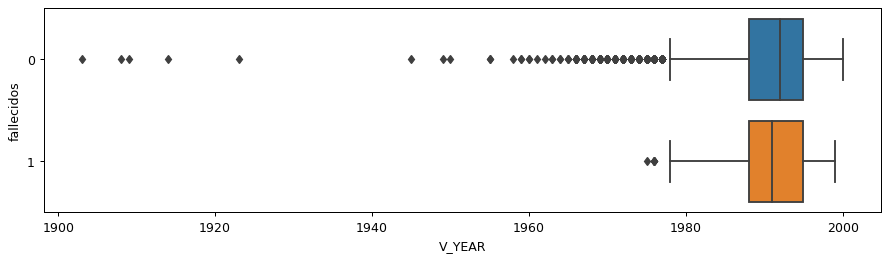

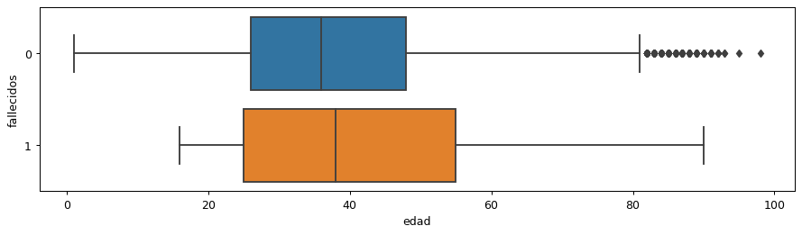

```python
for col in df_num:
    f, ax1 = plt.subplots(figsize=(12,3), dpi=90)
    ax = sns.boxplot(x=col, y= 'fallecidos', data=df_inicial, orient="h")
    ax.get_yaxis().set_visible(True)
```

Como se puede apreciar, en el boxplot de arriba se concentran los datos entre 1980 y el 2000, con presencia de algunos outliers en años anteriores.

Mirando la segunda gráfica, se confirma que el número de fallecidos y de accidentados se concentra en torno a los 25 y los 50-55 años de edad aproximadamente.

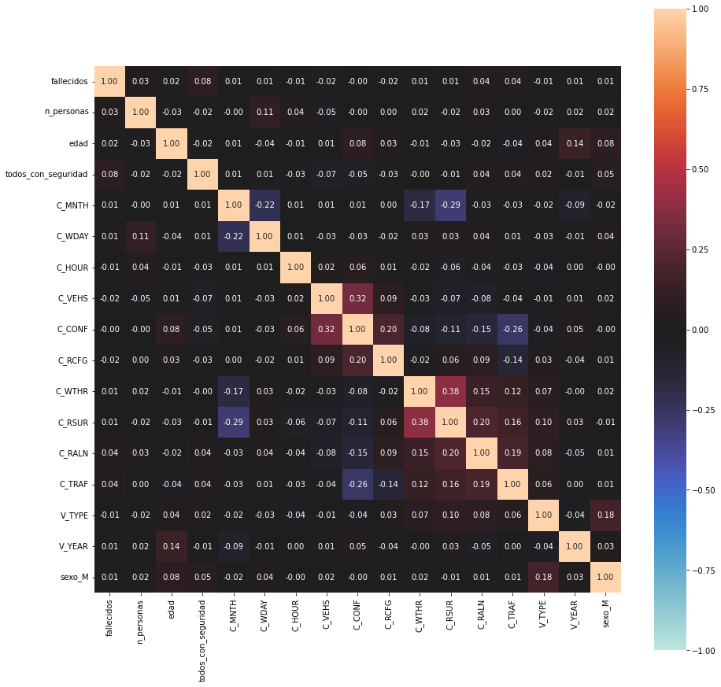

```python
# Plot features associations

associations(df_inicial, nom_nom_assoc='cramer', figsize=(15, 15));
```

Como podemos notar, no existen correlaciones significantes este las variables del Dataset, habiendo hasta valores en negativo.

### **Exportación del dataset de entrenamiento resultante.**

Guardamos de nuevo el CSV para su posterior modelado.

```python
df_inicial.to_csv('df_final.csv', index=False)
```